# AIML_ML_Project_full_code_SaiAdvaithVootukur

## Problem Statement

### Context

AllLife Bank is a US bank that has a growing customer base. The majority of these customers are liability customers (depositors) with varying sizes of deposits. The number of customers who are also borrowers (asset customers) is quite small, and the bank is interested in expanding this base rapidly to bring in more loan business and in the process, earn more through the interest on loans. In particular, the management wants to explore ways of converting its liability customers to personal loan customers (while retaining them as depositors).

A campaign that the bank ran last year for liability customers showed a healthy conversion rate of over 9% success. This has encouraged the retail marketing department to devise campaigns with better target marketing to increase the success ratio.

You as a Data scientist at AllLife bank have to build a model that will help the marketing department to identify the potential customers who have a higher probability of purchasing the loan.

### Objective

To predict whether a liability customer will buy personal loans, to understand which customer attributes are most significant in driving purchases, and identify which segment of customers to target more.

### Data Dictionary

- `ID`: Customer ID
- `Age`: Customer’s age in completed years
- `Experience`: #years of professional experience
- `Income`: Annual income of the customer (in thousand dollars)
- `ZIP Code`: Home Address ZIP code.
- `Family`: the Family size of the customer
- `CCAvg`: Average spending on credit cards per month (in thousand dollars)
- `Education`: Education Level. 1: Undergrad; 2: Graduate;3: Advanced/Professional
- `Mortgage`: Value of house mortgage if any. (in thousand dollars)
- `Personal_Loan`: Did this customer accept the personal loan offered in the last campaign? (0: No, 1: Yes)
- `Securities_Account`: Does the customer have securities account with the bank? (0: No, 1: Yes)
- `CD_Account`: Does the customer have a certificate of deposit (CD) account with the bank? (0: No, 1: Yes)
- `Online`: Do customers use internet banking facilities? (0: No, 1: Yes)
- `CreditCard`: Does the customer use a credit card issued by any other Bank (excluding All life Bank)? (0: No, 1: Yes)

## Importing necessary libraries

```python
# Installing the libraries with the specified version.
# !pip install numpy==1.25.2 pandas==1.5.3 matplotlib==3.7.1 seaborn==0.13.1 scikit-learn==1.2.2 sklearn-pandas==2.2.0 -q --user
```

**Note**:

1. After running the above cell, kindly restart the notebook kernel (for Jupyter Notebook) or runtime (for Google Colab), write the relevant code for the project from the next cell, and run all cells sequentially from the next cell.
2. On executing the above line of code, you might see a warning regarding package dependencies. This error message can be ignored as the above code ensures that all necessary libraries and their dependencies are maintained to successfully execute the code in this notebook.

```python
# Libraries to help with reading and manipulating data
import pandas as pd
import numpy as np

# libaries to help with data visualization
import matplotlib.pyplot as plt
import seaborn as sns
import plotly.express as px

# Library to split data
from sklearn.model_selection import train_test_split

# To build model for prediction
from sklearn.tree import DecisionTreeClassifier
from sklearn import tree

# to tune different models
from sklearn.model_selection import GridSearchCV

# To get diferent metric scores
from sklearn.metrics import (
    f1_score,
    accuracy_score,
    recall_score,
    precision_score,
    confusion_matrix,
)

# Libraries for scaling numerical features
from sklearn.preprocessing import StandardScaler

# to perform k-means clustering
from sklearn.cluster import KMeans

# to perform silhouette analysis
from sklearn.metrics import silhouette_score

# to perform t-SNE
from sklearn.manifold import TSNE

# to suppress unnecessary warnings
import warnings
warnings.filterwarnings("ignore")
```

## Loading the dataset

```python
from google.colab import drive
drive.mount('/content/drive')
```

```python
Loan_Model = pd.read_csv('/content/drive/My Drive/Colab Notebooks/Loan_Modelling.csv')
```

```python
LMCopy = Loan_Model.copy()
```

## Data Overview

- Observations
- Sanity checks

```python
print(LMCopy.head().to_string())
print('...........................')
print(LMCopy.tail().to_string())
print('...........................')
print(LMCopy.info())
print('...........................')
print(LMCopy.describe(include = 'all').to_string())
print('...........................')
print("\nThe following is the shape of the dataset in rows and columns, in that respective order:", LMCopy.shape)
print('...........................')
print(LMCopy.isnull().sum())
print('...........................')
print("\nThe following states how many duplicated values there are in the dataset:", LMCopy.duplicated().sum())
```

```
   ID  Age  Experience  Income  ZIPCode  Family  CCAvg  Education  Mortgage  Personal_Loan  Securities_Account  CD_Account  Online  CreditCard
0   1   25           1      49    91107       4    1.6          1         0              0                   1           0       0           0
1   2   45          19      34    90089       3    1.5          1         0              0                   1           0       0           0
2   3   39          15      11    94720       1    1.0          1         0              0                   0           0       0           0
3   4   35           9     100    94112       1    2.7          2         0              0                   0           0       0           0
4   5   35           8      45    91330       4    1.0          2         0              0                   0           0       0           1
...........................
        ID  Age  Experience  Income  ZIPCode  Family  CCAvg  Education  Mortgage  Personal_Loan  Securities_Account  CD_Account  Online  CreditCard
4995  4996   29           3      40    92697       1    1.9          3         0              0                   0           0       1           0
4996  4997   30           4      15    92037       4    0.4          1        85              0                   0           0       1           0
4997  4998   63          39      24    93023       2    0.3          3         0              0                   0           0       0           0
4998  4999   65          40      49    90034       3    0.5          2         0              0                   0           0       1           0
4999  5000   28           4      83    92612       3    0.8          1         0              0                   0           0       1           1
...........................
<class 'pandas.core.frame.DataFrame'>
RangeIndex: 5000 entries, 0 to 4999
Data columns (total 14 columns):
 #   Column              Non-Null Count  Dtype
---  ------              --------------  -----
 0   ID                  5000 non-null   int64
 1   Age                 5000 non-null   int64
 2   Experience          5000 non-null   int64
 3   Income              5000 non-null   int64
 4   ZIPCode             5000 non-null   int64
 5   Family              5000 non-null   int64
 6   CCAvg               5000 non-null   float64
 7   Education           5000 non-null   int64
 8   Mortgage            5000 non-null   int64
 9   Personal_Loan       5000 non-null   int64
 10  Securities_Account  5000 non-null   int64
 11  CD_Account          5000 non-null   int64
 12  Online              5000 non-null   int64
 13  CreditCard          5000 non-null   int64
dtypes: float64(1), int64(13)
memory usage: 547.0 KB
None
...........................
                ID          Age   Experience       Income       ZIPCode       Family        CCAvg    Education     Mortgage  Personal_Loan  Securities_Account  CD_Account       Online   CreditCard
count  5000.000000  5000.000000  5000.000000  5000.000000   5000.000000  5000.000000  5000.000000  5000.000000  5000.000000    5000.000000         5000.000000  5000.00000  5000.000000  5000.000000
mean   2500.500000    45.338400    20.104600    73.774200  93169.257000     2.396400     1.937938     1.881000    56.498800       0.096000            0.104400     0.06040     0.596800     0.294000
```

[output cut: 13 more lines]

```
Income                0
ZIPCode               0
Family                0
CCAvg                 0
Education             0
Mortgage              0
Personal_Loan         0
Securities_Account    0
CD_Account            0
Online                0
CreditCard            0
dtype: int64
...........................

The following states how many duplicated values there are in the dataset: 0
```

## Exploratory Data Analysis.

- EDA is an important part of any project involving data.
- It is important to investigate and understand the data better before building a model with it.
- A few questions have been mentioned below which will help you approach the analysis in the right manner and generate insights from the data.
- A thorough analysis of the data, in addition to the questions mentioned below, should be done.

**Questions**:

1. What is the distribution of mortgage attribute? Are there any noticeable patterns or outliers in the distribution?
2. How many customers have credit cards?
3. What are the attributes that have a strong correlation with the target attribute (personal loan)?
4. How does a customer's interest in purchasing a loan vary with their age?
5. How does a customer's interest in purchasing a loan vary with their education?

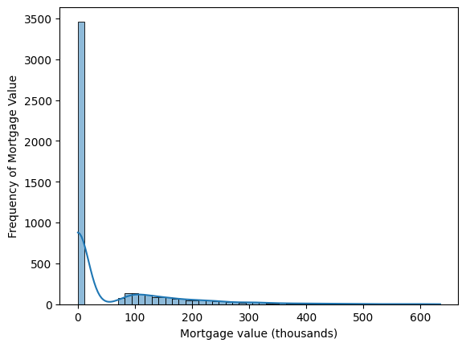

```python
# For question 1

sns.histplot(LMCopy, x='Mortgage', kde = True)
plt.xlabel('Mortgage value (thousands)')
plt.ylabel('Frequency of Mortgage Value')
plt.show()
```

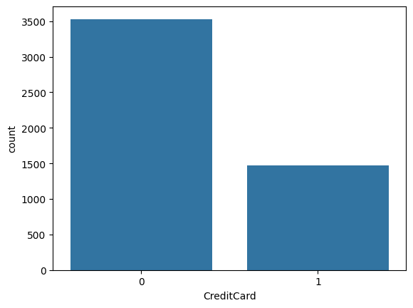

```
The total number of people who have and don't have a credit card:
CreditCard
0    3530
1    1470
Name: count, dtype: int64
(The customers who do not have a credit card fall under the category "0". Customers with a credit card fall under the category "1")
```

```python
# For question 2

sns.countplot(data = LMCopy, x = 'CreditCard')
plt.show()

TotalSplit = LMCopy['CreditCard'].value_counts()
print("The total number of people who have and don't have a credit card:\n", TotalSplit, sep='')
print('(The customers who do not have a credit card fall under the category "0". Customers with a credit card fall under the category "1")')
```

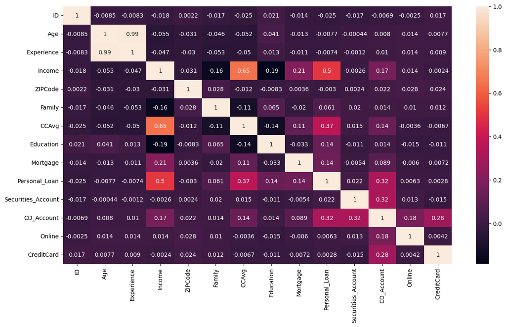

```python
# For question 3
plt.figure(figsize = (15, 8))
sns.heatmap(LMCopy.corr(), annot = True)
plt.show()
```

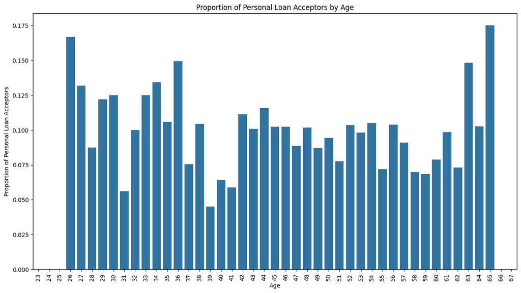

```python
# For question 4
Q4_Proportion = LMCopy.groupby('Age')['Personal_Loan'].mean().reset_index()
plt.figure(figsize=(15, 8))
sns.barplot(data=Q4_Proportion, x='Age', y='Personal_Loan')
plt.title('Proportion of Personal Loan Acceptors by Age')
plt.xlabel('Age')
plt.ylabel('Proportion of Personal Loan Acceptors')
plt.xticks(rotation=90) # Rotate x-axis labels for readability
plt.show()
```

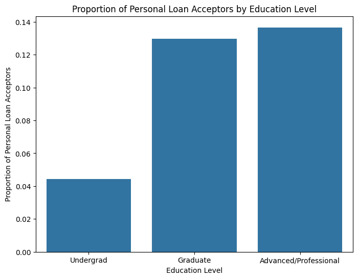

```python
# For question 5
Q5_Proportion = LMCopy.groupby('Education')['Personal_Loan'].mean().reset_index()
plt.figure(figsize=(8, 6))
sns.barplot(data=Q5_Proportion, x='Education', y='Personal_Loan')
plt.title('Proportion of Personal Loan Acceptors by Education Level')
plt.xlabel('Education Level')
plt.ylabel('Proportion of Personal Loan Acceptors')
plt.xticks(ticks=[0, 1, 2], labels=['Undergrad', 'Graduate', 'Advanced/Professional']) # Add meaningful labels
plt.show()
```

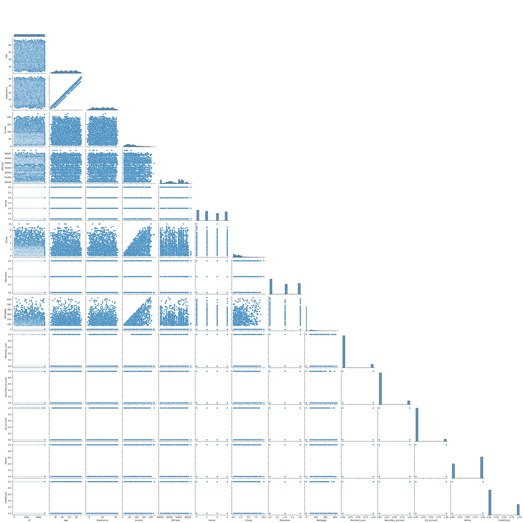

```python
sns.pairplot(LMCopy, corner=True)
plt.show()
```

We can see here that Age and Experience has a very strong positive correlation, meaning we could drop either Age or Experience if we wanted to from the dataset before modelling the data

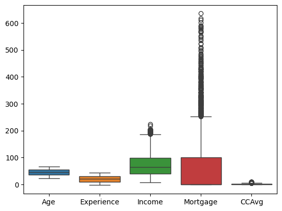

```python
sns.boxplot(LMCopy[['Age', 'Experience', 'Income', 'Mortgage', 'CCAvg']])
plt.show()
```

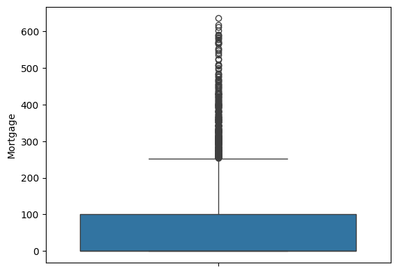

```python
sns.boxplot(LMCopy['Mortgage'])
plt.show()
```

We can see that Mortgage has quite a few outliers

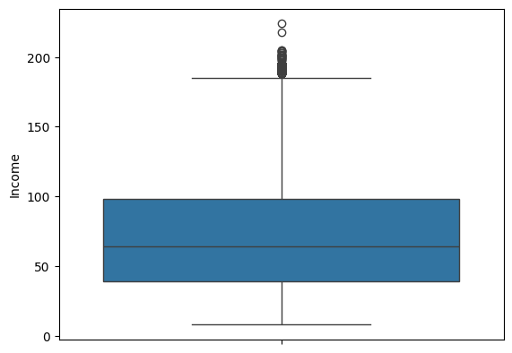

```python
sns.boxplot(LMCopy['Income'])
plt.show()
```

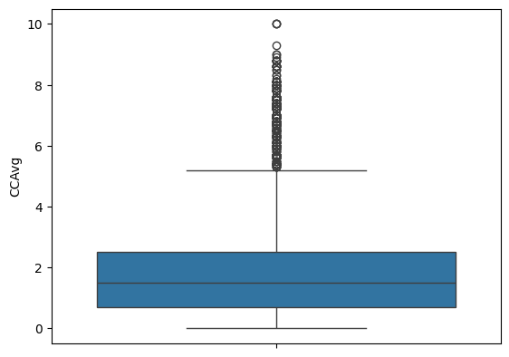

```python
sns.boxplot(LMCopy['CCAvg'])
plt.show()
```

We can see that CCAvg and Income also have quite a few outliers.